# GENERALIZED LINEAR MODELS

**Generalized Linear Models** are an extension of the the general linear model that mainly deal with **ordinal** and **categorical** response variables.

Linear models pose two major challenges when fitting them to data in that:

1. They ignore any interdependencies the variables may have
2. Assume the response variable is normally distributed, has a constant variance, and that all predictors are entered additively.

#### **Generalized Linear Model:**

$$g(µi) = β0 + β1xi1 + β2xi2 + · · ·
yi ∼ f(µi)$$
, *Where* **g** is a link function, such as the log or logit link and **f** is a probability distribution such as the binomial or Poisson.

The GLM model can alternatively be written as
$$µi = g^-1
(β0 + β1xi1 + β2xi2 + · · ·)
yi ∼ f(µi)$$

or
$$g(µi) = Xβ
yi ∼ f(µi)$$

GLMs have three main components:  
-Random Component  
-Systematic component  
-Link function

##### **The Random Component:**

The random component refers to the probability distribution of our response variable **Y**

**Case 1:** (Y1,Y2,….,Yn) might be normal. In this case, we would say the random component is the normal distribution. This component leads to ordinanry regression and **ANOVA** models.

**Case 2:** If the observations are Bernoulli random variables (Here we have valuse as 0 or 1), the we would say the link function is a binomial distribution. When the random component is the binomial distribution, we are commonly concerned with logistic regression or probit models.

**Case 3:** Quite often, the random variables Y1,Y2,….,Yn have a poison distribution. Then we will be involved with poisson regression or loglinear models.

##### **The Systemic Component:**

The systemic component involves the explanatory variables X1,X2,…,Xk as our linear predictors:
$$β0 + β1X1 + β2X2 + · · ·βkXk$$

##### **The Link Function:**

The third component of a GLM is the link between the random and systematic components. It explains how the mean
$$μ=E(Y)$$
relates to the explanatory variables in the linear predictor through specifying a function
$$g(μ)$$
hence
$$g(µi) = β0 + β1xi1 + β2xi2 + · · ·
yi ∼ f(µi)$$

> An inverse link function (g−1) transforms values from the (−∞, ∞) scale to the scale of interest, such as (0, 1) for probabilities. The link function (g) does the reverse.

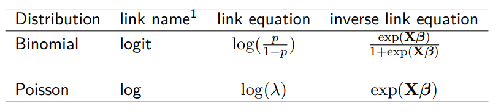

##### Logit Link Example:

```r
beta0 <- 5
beta1 <- -0.08
elevation <- 100
(logit.p <- beta0+beta1*elevation)
```

The resulting value can be converted into a probability by getting its inverse link.

```r
p <- exp(logit.p)/(1+exp(logit.p))
p
```

To revert to the link function iself:

```r
log(p/(1-p))
```

```r
plot(function(x) 5 + -0.08*x, from=0, to=100,
xlab="Elevation", ylab="logit(prob of occurrence)")

plot(function(x) plogis(5 + -0.08*x), from=0, to=100,
xlab="Elevation", ylab="Probability of occurrence")
```

[output not shown]

#### **Linear Model:**

$$µi = β0 + β1xi1 + β2xi2 + · · ·
yi ∼ Normal(µi
, σ2
)$$
Assume that
$$Yi∼N(μi,σ2)$$
(the Gaussian distribution is an exponential family distribution.), we can define the linearb predictor for our linear model to be
$$ηi=∑pk=1 Xikβk.$$

The link function as **g** so that **g(μ)=η**. This function links the mean of the Y’s to the linear predictor. Therefore, for linear models
$$g(μ)=μ$$
so that
$$μi=ηi$$
.

This yields the same likelihood model as our additive error Gaussian linear model

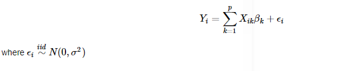

#### **Logistic Regression**

Assume that our outcome is Bernoulli,
$$Yi∼Bernoulli(μi)$$
so that
$$E[Yi]=μi where 0≤μi≤1.$$
. We define linear predictor
$$ηi=∑pk=1Xikβk$$
. It looks like our regression model.
The link function that links the mean of the Y’s to the linear predictor is
$$g(μ)=η=log(μ/1−μ)$$
. **g** is the (natural) log odds, referred to as the **logit**.

Note then we can invert the logit function as

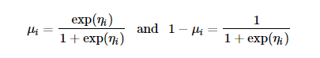

Thus (according to the Bernoulli liklihood) the likelihood for all of the muus is

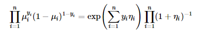

#### **Poisson Regression**

Assume that
$$Yi∼Poisson(μi)$$
so that
$$E[Yi]=μi$$
where
$$0≤μi$$
. We define linear predictor
$$ηi=∑pk=1Xikβk$$
. And the link function
$$g(μ)=η=log(μ)$$
. Recall that
$$e^x$$
is the inverse of *log(x)* so that
$$μi=e^ηi$$
, thus the likelihood is

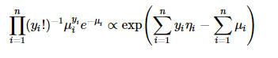

#### **Variances and quasi likelihood.**

One thing to note is that for all the above cases, the only way in which the likelihood depends on the data is through

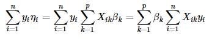

For the linear model
$$Var(Yi)=σ2$$
is constant.

For Bernoulli case
$$Var(Yi)=μi(1−μi)$$

For the Poisson case
$$Var(Yi)=μi.$$

In the latter cases, it is often relevant to have a more flexible variance model, even if it doesn’t correspond to an actual likelihood

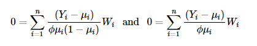

. where *Wi* are the derivatives of the inverse of the link function. These are called **quasi-likelihood** normal equations .

> The whole point is to relax these strict assumption relating the means and the variances in those two models. And it simply fits the standard normal equations, but throws an extra parameter down there in the denominator. They inherit most of the properties that glm’s do but without corresponding to a specific model.

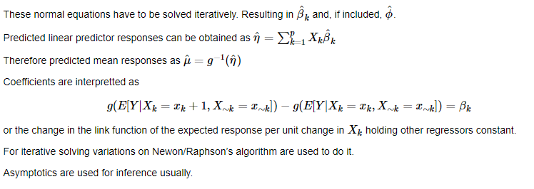

#### **GLMs: Binary Outcomes.**

#### Example:

Safaricom stock price data,2015-2020

```r
library(knitr)
library(printr)
safcom <- read.csv("./safcom.csv")
kable(head(safcom,10),align = 'c')
```

| TransactionDate | Name | MarketPrice | Returns | Result | X | BenchMark.Name | Value | X.1 | NSE |
| --- | --- | --- | --- | --- | --- | --- | --- | --- | --- |
| 01-Apr-19 | Safaricom Ltd Ord 0.05 | 27.90 | NA | 0 | NA | Nairobi All Share Index | 159.01 | NA | 0 |
| 02-Apr-19 | Safaricom Ltd Ord 0.05 | 28.10 | 0.0071685 | 1 | NA | Nairobi All Share Index | 159.76 | 0.0047167 | 1 |
| 03-Apr-19 | Safaricom Ltd Ord 0.05 | 28.10 | 0.0000000 | 0 | NA | Nairobi All Share Index | 160.08 | 0.0020030 | 1 |
| 04-Apr-19 | Safaricom Ltd Ord 0.05 | 28.05 | -0.0017794 | 0 | NA | Nairobi All Share Index | 159.58 | -0.0031234 | 0 |
| 05-Apr-19 | Safaricom Ltd Ord 0.05 | 28.00 | -0.0017825 | 0 | NA | Nairobi All Share Index | 159.52 | -0.0003760 | 0 |
| 06-Apr-19 | Safaricom Ltd Ord 0.05 | 28.00 | 0.0000000 | 0 | NA | Nairobi All Share Index | 159.52 | 0.0000000 | 0 |
| 07-Apr-19 | Safaricom Ltd Ord 0.05 | 28.00 | 0.0000000 | 0 | NA | Nairobi All Share Index | 159.52 | 0.0000000 | 0 |
| 08-Apr-19 | Safaricom Ltd Ord 0.05 | 28.00 | 0.0000000 | 0 | NA | Nairobi All Share Index | 159.24 | -0.0017553 | 0 |
| 09-Apr-19 | Safaricom Ltd Ord 0.05 | 27.85 | -0.0053571 | 0 | NA | Nairobi All Share Index | 158.39 | -0.0053379 | 0 |
| 10-Apr-19 | Safaricom Ltd Ord 0.05 | 27.75 | -0.0035907 | 0 | NA | Nairobi All Share Index | 158.20 | -0.0011996 | 0 |

#### **Linear Regression:**

Fitting a linear regression model here would work fairly good. The additive error term however makes it that our outcome isn’t a 0 or a 1, if the error is continuous.
$$SPi=b0 + b1IVi+ei$$

*SPi* - 1 if we make profit, 0 if not

*b0* - probability of a profit if the market is at zero.

*b1* - increase in probability of a profit for each additional value in the index.

*ei* - residual variation due

```r
lmSaf <- lm(safcom$Result ~ safcom$Value)
summary(lmSaf)
```

[output not shown]

The above case aids in predicting the profit within a thresh held linear regression model. A predictive model however would need more than that, hence the need for interpretation. From a machine learning perspective, depending on the loss function a linear regression might be perfectly reasonable for binary outcomes. But, for interoperability, you want something different, so we re-frame the model in a particularly interpretable way using odds.

#### **Odds:**

#### **Binary Outcome 0/1**

$$SPi$$
**Probability (0,1) :** We could talk about the probability that we made profit, given the parameters and the index , what was the index value:
$$Pr(SPi|IVi,b0,b1)$$

**Odds (0,∞) :** The odds are the probability over one minus the probability:
$$Pr(SPi|IVi,b0,b1)/(1-Pr(SPi|IVi,b0,b1))$$

**Log odds (−∞,∞) :** The log odds*(Logit)*
$$log(Pr(SPi|IVi,b0,b1)/(1-Pr(SPi|IVi,b0,b1)))$$

#### **Linear vs. logistic regression:**

So the Linear regression models this

$$SPi=b0+b1IVi+ei$$
or
$$E[SPi|IVi,b0,b1]=b0+b1IVi$$

and Logistic regression models
$$Pr(SPi|IVi,b0,b1)=exp(b0+b1IVi)/1+exp(b0+b1IVi)$$
or
$$log(Pr(SPi|IVi,b0,b1)/1−Pr(SPi|IVi,b0,b1))=b0+b1IVi$$

#### **Interpreting Logistic Regression**

Rewriting the logistic regression equation gives us:

$$log(Pr(SPi|IVi,b0,b1)/1−Pr(SPi|IVi,b0,b1))=b0+b1IVi$$
And the interpretations would be:
**b0** - Log odds of a SafProfit if the market was at zero.

**b1** - Log odds ratio of profit probability for each index value accrued (compared to zero value). ( if we had other covariates, we’d have to add the phrase with all the covariates held fixed.)

**exp(b1)** - Odds ratio of profit probability for each index value accrued (compared to zero value)